# INN Hotels Project

### Observations:

**it is logical to assume that most reservations are either business associates sharing a room or couples with no children. There is no relationship between no_of_children adn booking status.**

### Booking Status vs Number of Weekend Nights

```
booking_status            0      1    All
no_of_weekend_nights
All                   24390  11885  36275
0                     11779   5093  16872
1                      6563   3432   9995
2                      5914   3157   9071
4                        46     83    129
3                        79     74    153
5                         5     29     34
6                         4     16     20
7                         0      1      1
------------------------------------------------------------------------------------------------------------------------
```

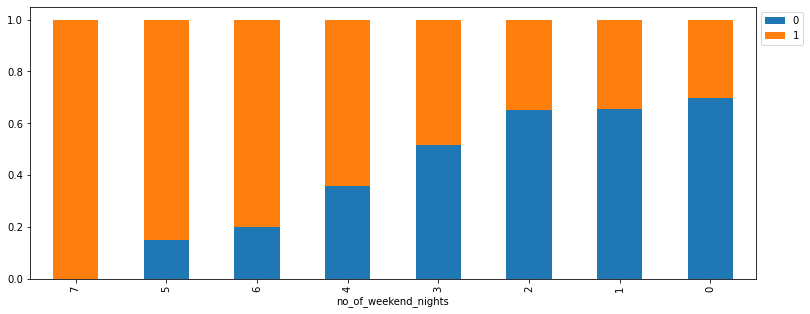

```python
stacked_barplot(
    data, "no_of_weekend_nights", "booking_status"
)  # creates stacked barplot of booking status with respect to number of weekend nights
```

### Observations:

**It seems safe to say that the greater the number of weekend nights that are reserved the greater the chance will be that a reservation is canceled.**

### Booking Status vs Number of Week Nights

```
booking_status         0      1    All
no_of_week_nights
All                24390  11885  36275
2                   7447   3997  11444
3                   5265   2574   7839
1                   6916   2572   9488
4                   1847   1143   2990
0                   1708    679   2387
5                    982    632   1614
6                    101     88    189
10                     9     53     62
7                     61     52    113
8                     30     32     62
9                     13     21     34
11                     3     14     17
15                     2      8     10
12                     2      7      9
13                     0      5      5
14                     3      4      7
16                     0      2      2
17                     1      2      3
------------------------------------------------------------------------------------------------------------------------
```

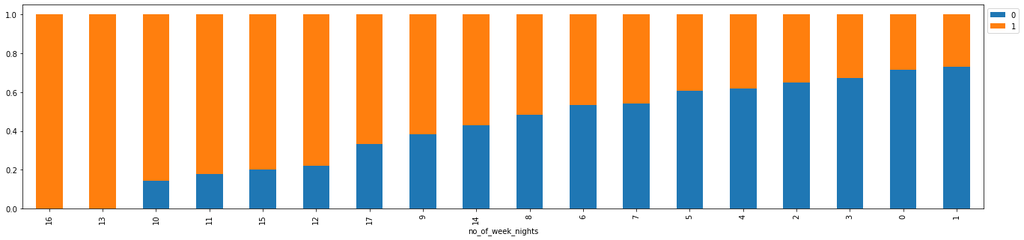

```python
stacked_barplot(
    data, "no_of_week_nights", "booking_status"
)  # creates stacked barplot of booking status with respect to number of week nights
```

### Observations:

**It is okay to assume that the greater the number of weeknights reserved/booked, the greater the chances are that the reservation will be cancelled for week nights which is similar to that of weekend nights. In total, the higher the number of nights, the greater the chances are that the reservation will be cancelled**

### Booking Status vs Type of Meal Plan

```
booking_status         0      1    All
type_of_meal_plan
All                24390  11885  36275
Meal Plan 1        19156   8679  27835
Not Selected        3431   1699   5130
Meal Plan 2         1799   1506   3305
Meal Plan 3            4      1      5
------------------------------------------------------------------------------------------------------------------------
```

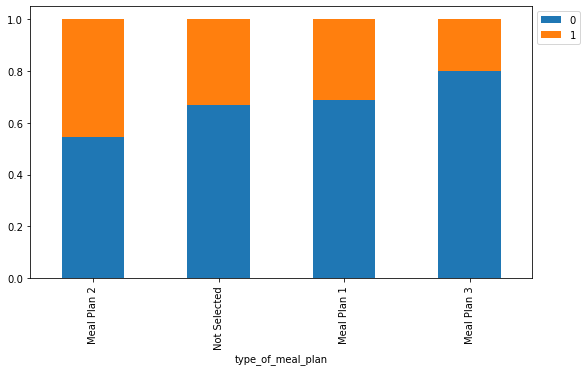

```python
stacked_barplot(
    data, "type_of_meal_plan", "booking_status"
)  # creates stacked barplot of booking status with respect to type of meal plan
```

### Observations:

**The 3rd meal plan happens to have the richest meals included in its menu hence its an indicator that people who make reservations with this meal plan seldomly cancel their reservations as seen from the graph.**

### Booking Status vs Required Car Parking Space

```
booking_status                  0      1    All
required_car_parking_space
All                         24390  11885  36275
0                           23380  11771  35151
1                            1010    114   1124
------------------------------------------------------------------------------------------------------------------------
```

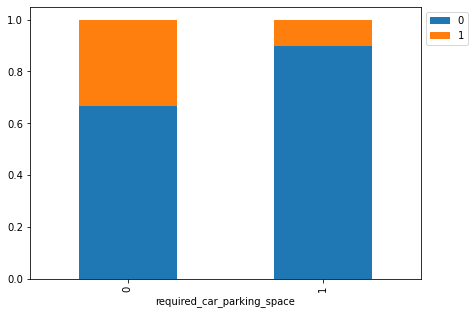

```python
stacked_barplot(
    data, "required_car_parking_space", "booking_status"
)  # creates stacked barplot of booking status with respect to required car parking space
```

### Observations:

**The graph suggest that if a car parking space is required by an individual, it is unlikely that the reservation wil be cancelled**

### Booking Status vs Room Type Reserved

```
booking_status          0      1    All
room_type_reserved
All                 24390  11885  36275
Room_Type 1         19058   9072  28130
Room_Type 4          3988   2069   6057
Room_Type 6           560    406    966
Room_Type 2           464    228    692
Room_Type 5           193     72    265
Room_Type 7           122     36    158
Room_Type 3             5      2      7
------------------------------------------------------------------------------------------------------------------------
```

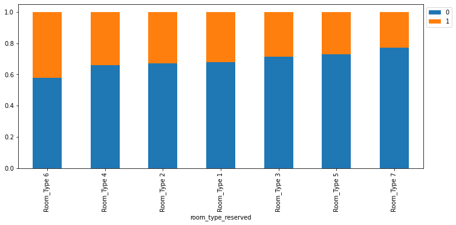

```python
stacked_barplot(
    data, "room_type_reserved", "booking_status"
)  # creates stacked barplot of booking status with respect to room type reserved
```

### Observations:

**People who go for room type 7 are less likely to cancel their reservation as shown from the graph**

### Booking Status vs Arrival Year

```
booking_status      0      1    All
arrival_year
All             24390  11885  36275
2018            18837  10924  29761
2017             5553    961   6514
------------------------------------------------------------------------------------------------------------------------
```

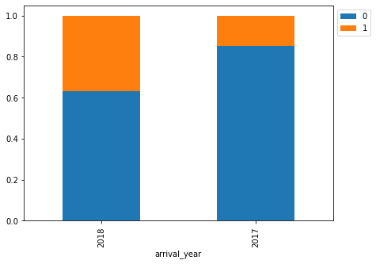

```python
stacked_barplot(
    data, "arrival_year", "booking_status"
)  # creates stacked barplot of booking status with respect to arrival year
```

### Observations:

**There was an increase in cancellation rate from 2017 to 2018**

### Booking Status vs Arrival Month

```
booking_status      0      1    All
arrival_month
All             24390  11885  36275
10               3437   1880   5317
9                3073   1538   4611
8                2325   1488   3813
7                1606   1314   2920
6                1912   1291   3203
4                1741    995   2736
5                1650    948   2598
11               2105    875   2980
3                1658    700   2358
2                1274    430   1704
12               2619    402   3021
1                 990     24   1014
------------------------------------------------------------------------------------------------------------------------
```

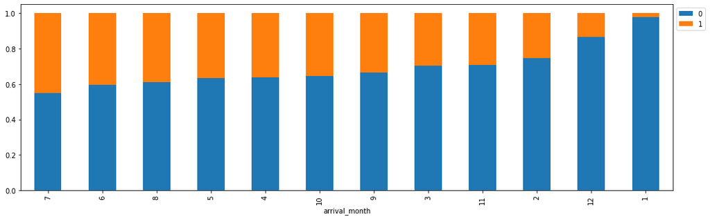

```python
stacked_barplot(
    data, "arrival_month", "booking_status"
)  # creates stacked barplot of booking status with respect to arrival month
```

### Observations:

**It seems that the months where it is likely to be cold like December, january,february,march,april & may have less of a chance of cancellation then compared to the warmer summer months.**

### Booking Status vs Market Segment Type

```
booking_status           0      1    All
market_segment_type
All                  24390  11885  36275
Online               14739   8475  23214
Offline               7375   3153  10528
Corporate             1797    220   2017
Aviation                88     37    125
Complementary          391      0    391
------------------------------------------------------------------------------------------------------------------------
```

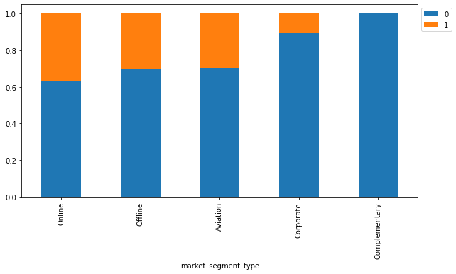

```python
stacked_barplot(
    data, "market_segment_type", "booking_status"
)  # creates stacked barplot of booking status with respect to market segment type
```

### Observations:

**Complementary has no cancellations which makes sense since it is a free trip for the customer. Corporate is second which also makes sense since these reservations are for businees trips, and must be attended. These are also typically paid for by the company and not the employee staying in the room. Seeing how little the amount of corporate reservations there are, it is safe to believe that the majority of the resrvations are from couples with no children.**

### Booking Status vs Repeated Guest

```
booking_status      0      1    All
repeated_guest
All             24390  11885  36275
0               23476  11869  35345
1                 914     16    930
------------------------------------------------------------------------------------------------------------------------
```

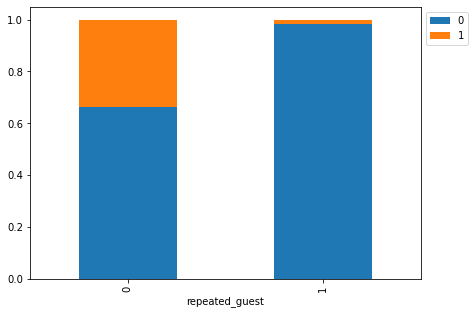

```python
stacked_barplot(
    data, "repeated_guest", "booking_status"
)  # creates stacked barplot of booking status with respect to repeated guest
```

### Observations:

**Repeated guests tend to come back to make a reservation. This might be indicative of the fact that they get discounts as they are now recognized as loyal customers**

### Booking Status vs Number of Previous Cancellations

```
booking_status                    0      1    All
no_of_previous_cancellations
All                           24390  11885  36275
0                             24068  11869  35937
1                               187     11    198
13                                0      4      4
3                                42      1     43
2                                46      0     46
4                                10      0     10
5                                11      0     11
6                                 1      0      1
11                               25      0     25
------------------------------------------------------------------------------------------------------------------------
```

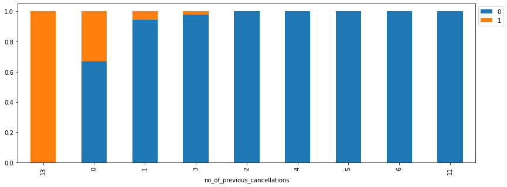

```python
stacked_barplot(
    data, "no_of_previous_cancellations", "booking_status"
)  # creates stacked barplot of booking status with respect to number of previous cancellations
```

```python
data[data["no_of_previous_cancellations"] == 13]
```

|  | no_of_adults | no_of_children | no_of_weekend_nights | no_of_week_nights | type_of_meal_plan | required_car_parking_space | room_type_reserved | lead_time | arrival_year | arrival_month | arrival_date | market_segment_type | repeated_guest | no_of_previous_cancellations | no_of_previous_bookings_not_canceled | avg_price_per_room | no_of_special_requests | booking_status |
| --- | --- | --- | --- | --- | --- | --- | --- | --- | --- | --- | --- | --- | --- | --- | --- | --- | --- | --- |
| 12097 | 2 | 0 | 1 | 1 | Meal Plan 1 | 0 | Room_Type 1 | 190 | 2018 | 4 | 9 | Offline | 1 | 13 | 1 | 70.00000 | 0 | 1 |
| 12109 | 2 | 0 | 1 | 1 | Meal Plan 1 | 0 | Room_Type 1 | 190 | 2018 | 4 | 9 | Offline | 1 | 13 | 1 | 70.00000 | 0 | 1 |
| 16277 | 2 | 0 | 1 | 1 | Meal Plan 1 | 0 | Room_Type 1 | 190 | 2018 | 4 | 9 | Offline | 1 | 13 | 1 | 70.00000 | 0 | 1 |
| 30833 | 2 | 0 | 1 | 1 | Meal Plan 1 | 0 | Room_Type 1 | 190 | 2018 | 4 | 9 | Offline | 1 | 13 | 1 | 70.00000 | 0 | 1 |

### observation

**The 13 seems to be an outlier that should be removed, since the 4 occurences of this value have all the exact same feature values for all data points. Thus, these four occurences should be removed. A person who has previously canceled is sure to book a reservation most of the time.**

### Booking Status vs Number of Previous Bookings not Canceled

```
booking_status                            0      1    All
no_of_previous_bookings_not_canceled
All                                   24390  11885  36275
0                                     23585  11878  35463
1                                       224      4    228
12                                       11      1     12
4                                        64      1     65
6                                        35      1     36
2                                       112      0    112
44                                        2      0      2
43                                        1      0      1
42                                        1      0      1
41                                        1      0      1
40                                        1      0      1
38                                        1      0      1
```

[output cut: 48 more lines]

[figure not shown]

```python
stacked_barplot(
    data, "no_of_previous_bookings_not_canceled", "booking_status"
)  # creates stacked barplot of booking status with respect to number of previous bookings not canceled
```

```python
data[data["no_of_previous_bookings_not_canceled"] != 0]["booking_status"].value_counts()
```

```
0    805
1      7
Name: booking_status, dtype: int64
```

### Booking Status vs Number of Special Requests

```
booking_status              0      1    All
no_of_special_requests
All                     24390  11885  36275
0                       11232   8545  19777
1                        8670   2703  11373
2                        3727    637   4364
3                         675      0    675
4                          78      0     78
5                           8      0      8
------------------------------------------------------------------------------------------------------------------------
```

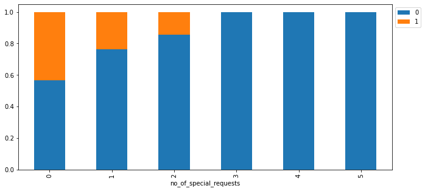

```python
stacked_barplot(
    data, "no_of_special_requests", "booking_status"
)  # creates stacked barplot of booking status with respect to number of special requests
```

### Observations:

**As the number of specail requests rises the number of cancellations decreases. This makes sense as the number of specail request that increase means the customer is more picky and less likely/willing to cancel since all their needs are being met.**

## Question 1: What are the busiest months in the hotel?

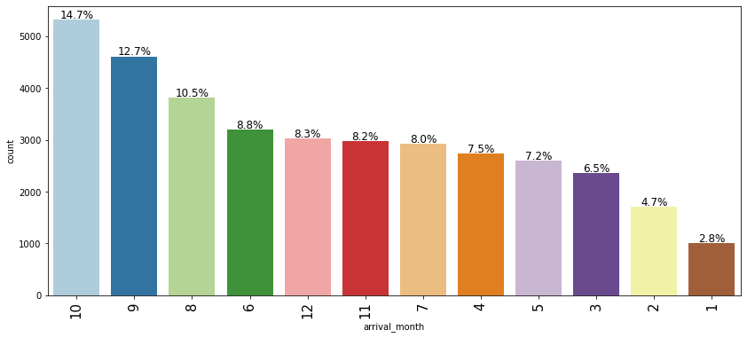

```python
labeled_barplot(
    data, "arrival_month", perc=True
)  # creates a labeled barplot showing the busiest months with their coresponding percentages
```

### Observation

**October is the busiest month**

**People tend to travel during latter months and those are holiday periods hence the reason why the hotel is busy duringb this period**